# Chapter 1: Exercise 2

Colin Gillespie

2017-09-27

## Markdown chunk option

For each knitr code chunk option below

1. Experiment with the different options.
2. Re-render the file to see what the option does. If you cannot tell, re-render the file both with and without the code chunk.
3. Describe in your own words what the option does.
4. Use the RStudio’s auto complete function; this is accessed via the TAB key.

### eval

- What happens when `eval=TRUE`?
- What is the default?

**eval=FALSE**

```r
colMeans(cars)
1 + 1
```

**eval=TRUE**

```r
colMeans(cars)
```

```
## speed  dist
## 15.40 42.98
```

```r
1 + 1
```

```
## [1] 2
```

Description: eval TRUE –> evaluates codes in the chunck and includes results ***

### results

- Other options for results is `markup` and `asis`
- What is the default?

**results = ‘hide’**

```r
carmeans = colMeans(cars)
1 + 1
```

**results = ‘markup’**

```r
carmeans = colMeans(cars)
1 + 1
```

```
## [1] 2
```

**results = ‘asis’**

```r
carmeans = colMeans(cars)
1 + 1
```

[1] 2

Description: markup: mark up the results using the output hook, e.g. put results in a special LaTeX environment

asis: output as-is, i.e., write raw results from R into the output document. knitr will pass through results without reformatting them (useful if results return raw HTML, etc.)

If ‘hide’, knitr will not display the code’s results in the final document.

If ‘hold’, knitr will delay displaying all output pieces until the end of the chunk. ***

### echo

- Try `echo=TRUE`. What’s the default value for `echo`?

**echo = FALSE**

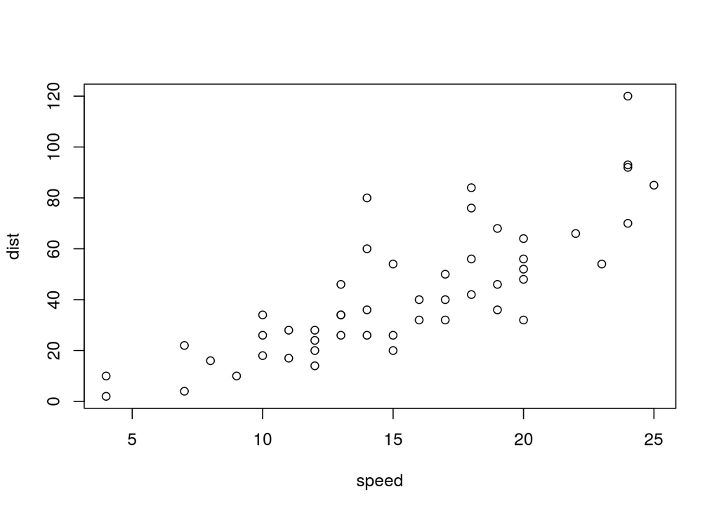

**echo = TRUE**

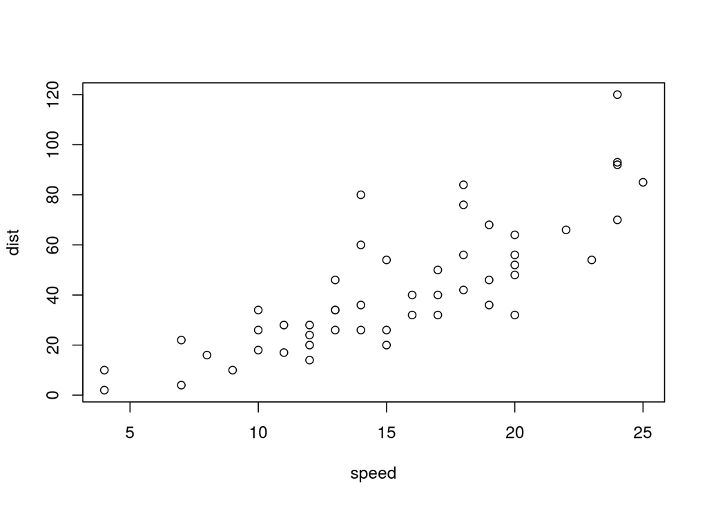

```r
plot(cars)
```

Description:

echo: (TRUE; logical or numeric) whether to include R source code in the output file; besides TRUE/FALSE which completely turns on/off the source code, we can also use a numeric vector to select which R expression(s) to echo in a chunk, e.g. echo=2:3 means only echo the 2nd and 3rd expressions, and echo=-4 means to exclude the 4th expression

### fig.width and fig.height

When adding multiple arguments to a code chunk, separate the arguments by a comma.

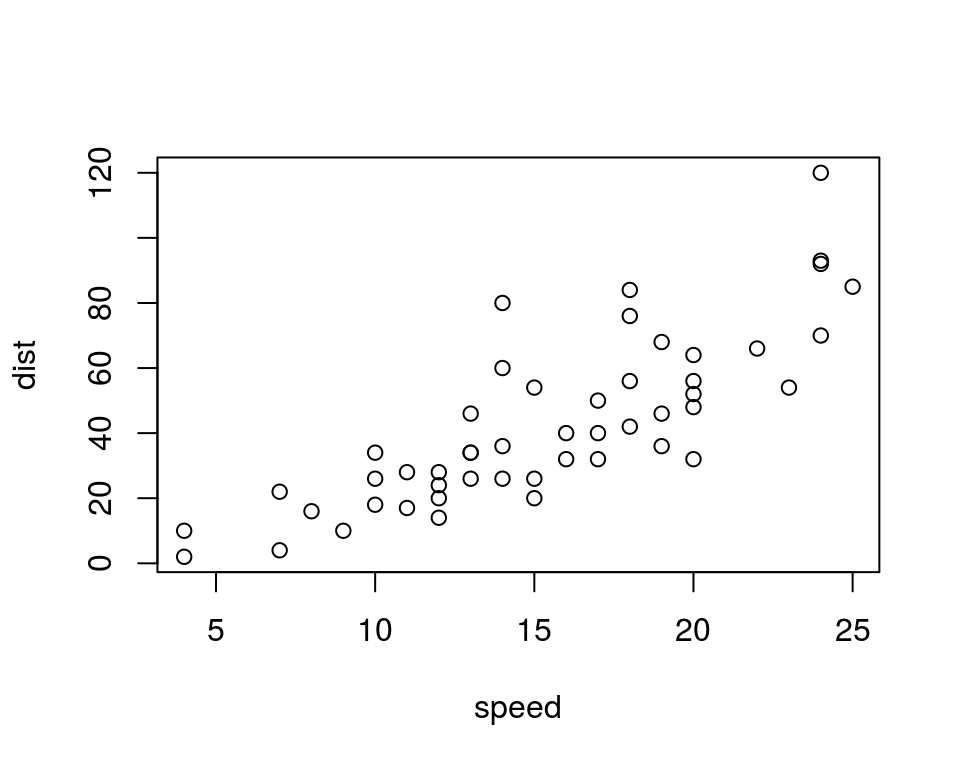

```r
plot(cars)
```

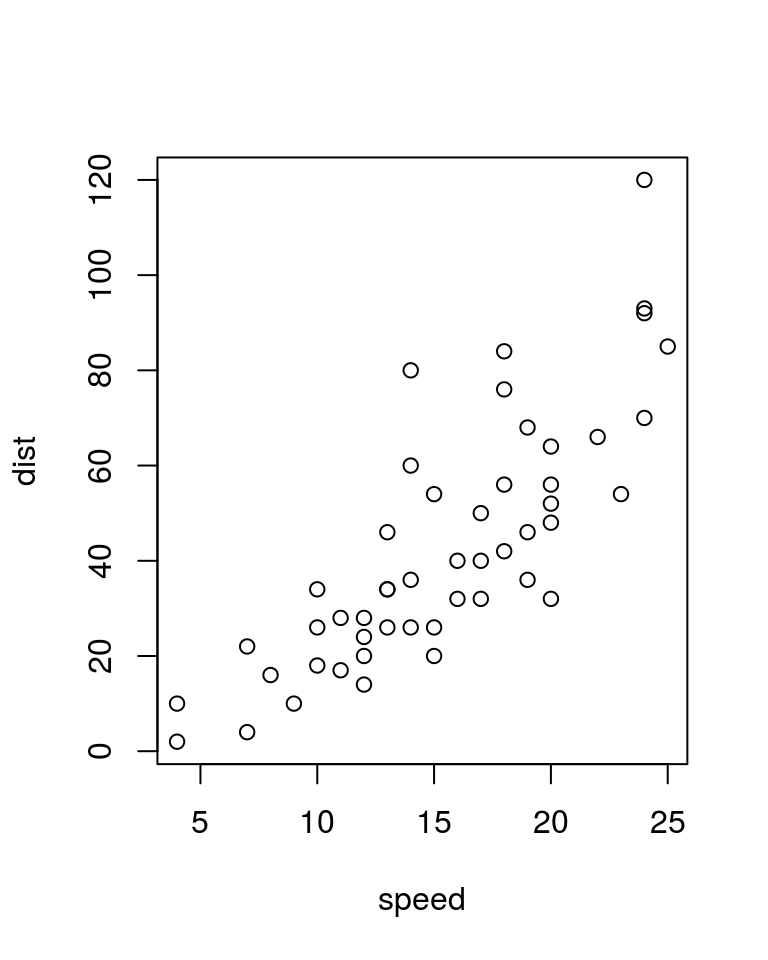

```r
plot(cars)
```

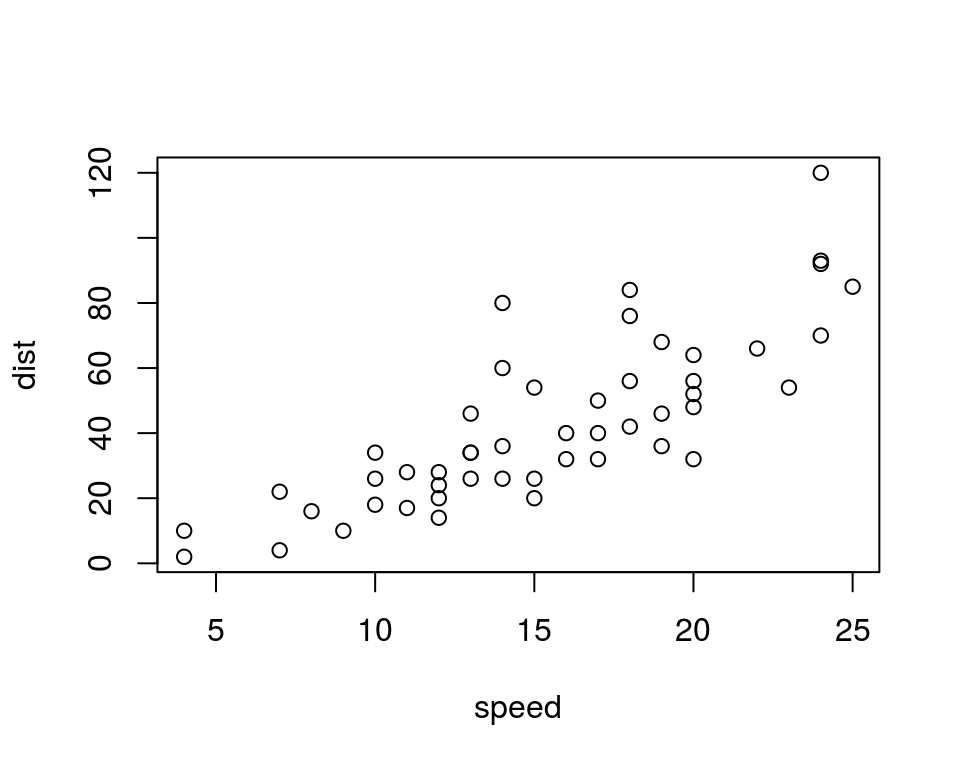

```r
plot(cars)
```

Description:

fig.width and fig.height control the span of a figure. (How about position?)

fig.align: (‘default’; character) alignment of figures in the output document (possible values are left, right and center; default is not to make any alignment adjustments).

### message

```r
f = function(x) {
  message("Thanks")
  return(x)
}
f(10)
```

```
## [1] 10
```

```r
f = function(x) {
  message("Thanks")
  return(x)
}
f(10)
```

```
## Thanks
```

```
## [1] 10
```

Description:

(TRUE; logical) whether to preserve messages emitted by message() (similar to warning) ***